# Project_Full_Code_Notebook_EasyVisa_final

# **Model Comparison and Final Model Selection**

```python
# training performance comparison

models_train_comp_df = pd.concat(
    [
        rf_tuned_model_train_perf.T,
        abc_tuned_model_train_perf.T,
        gbc_tuned_model_train_perf.T,
        xgb_tuned_model_train_perf.T,
    ],
    axis=1,
)
models_train_comp_df.columns = [
    "Tuned Random Forest",
    "Tuned Adaboost Classifier",
    "Tuned Gradient Boost Classifier",
    "XGBoost Classifier Tuned",
]
print("Training performance comparison:")
models_train_comp_df
```

```
Training performance comparison:
```

|  | Tuned Random Forest | Tuned Adaboost Classifier | Tuned Gradient Boost Classifier | XGBoost Classifier Tuned |
| --- | --- | --- | --- | --- |
| Accuracy | 0.771782 | 0.751897 | 0.753205 | 0.757457 |
| Recall | 0.912243 | 0.884133 | 0.886288 | 0.883643 |
| Precision | 0.782229 | 0.775715 | 0.776005 | 0.781667 |
| F1 | 0.842248 | 0.826383 | 0.827488 | 0.829533 |

```python
# validation performance comparison
models_val_comp_df = pd.concat(
    [
        rf_tuned_model_val_perf.T,
        abc_tuned_model_val_perf.T,
        gbc_tuned_model_val_perf.T,
        xgb_tuned_model_val_perf.T,
    ],
    axis=1,
)
models_val_comp_df.columns = [
    "Tuned Random Forest",
    "Tuned Adaboost Classifier",
    "Tuned Gradient Boost Classifier",
    "XGBoost Classifier Tuned",
]
print("Validation performance comparison:")
models_val_comp_df
```

```
Validation performance comparison:
```

|  | Tuned Random Forest | Tuned Adaboost Classifier | Tuned Gradient Boost Classifier | XGBoost Classifier Tuned |
| --- | --- | --- | --- | --- |
| Accuracy | 0.747645 | 0.751374 | 0.754121 | 0.751962 |
| Recall | 0.894242 | 0.883373 | 0.884548 | 0.874559 |
| Precision | 0.766751 | 0.775600 | 0.777835 | 0.780545 |
| F1 | 0.825603 | 0.825985 | 0.827766 | 0.824882 |

```python
# Let's test the tuned models on the test set. performance comparison
models_test_comp_df = pd.concat(
    [
        rf_tuned_model_test_perf.T,
        abc_tuned_model_test_perf.T,
        gbc_tuned_model_test_perf.T,
        xgb_tuned_model_test_perf.T,
    ],
    axis=1,
)
models_test_comp_df.columns = [
    "Tuned Random Forest",
    "Tuned Adaboost Classifier",
    "Tuned Gradient Boost Classifier",
    "XGBoost Classifier Tuned",
]
print("Test performance comparison:")
models_test_comp_df
```

```
Test performance comparison:
```

|  | Tuned Random Forest | Tuned Adaboost Classifier | Tuned Gradient Boost Classifier | XGBoost Classifier Tuned |
| --- | --- | --- | --- | --- |
| Accuracy | 0.736656 | 0.739207 | 0.737441 | 0.740973 |
| Recall | 0.889542 | 0.878085 | 0.877791 | 0.874559 |
| Precision | 0.758137 | 0.765821 | 0.764194 | 0.769251 |
| F1 | 0.818600 | 0.818120 | 0.817063 | 0.818532 |

## Best and Final Model: Tuned Gradient Boosting Classifier

**Why the notebook supports this conclusion:**

1. **Highest validation F1 (0.828)** — validation is the correct set for model selection, not test
2. **Virtually zero overfitting** — train F1 (0.828) ≈ val F1 (0.828), the tightest train/val gap of any model
3. **Most stable throughout** — GBC led validation F1 across all three sampling strategies (original, SMOTE, undersampling)
4. **Balanced precision/recall** — better precision than AdaBoost, better recall than XGBoost, sitting in the optimal middle ground for visa certification decisions
5. **Highest validation accuracy (0.754)**

## Important features of the final model

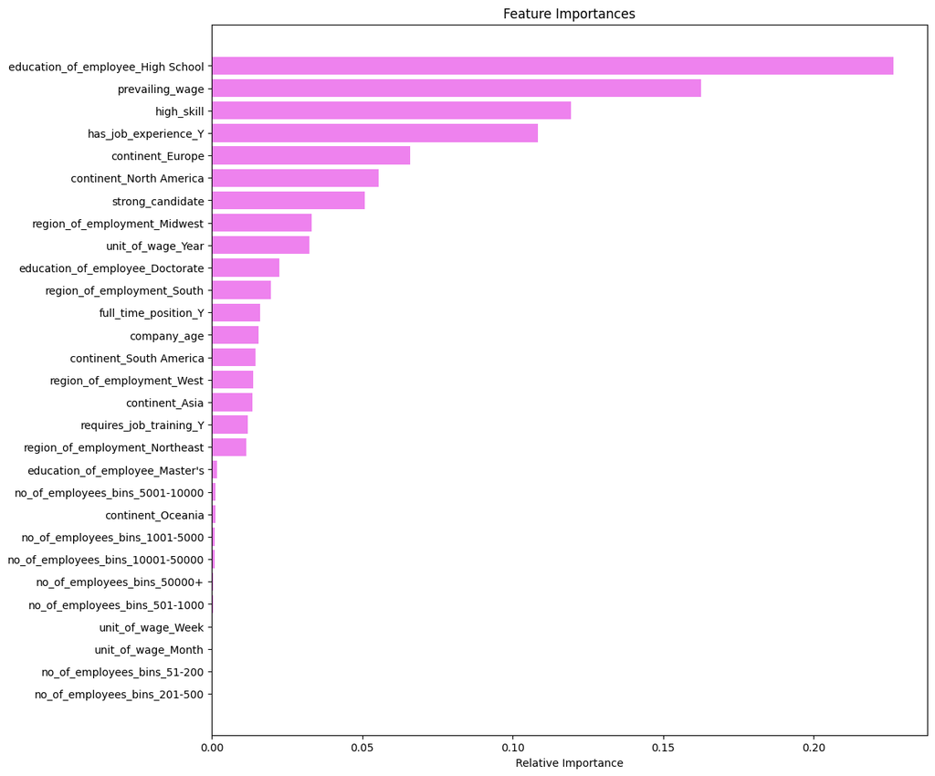

```python
## get the feature importances of the best model
feature_names = X_train.columns
importances = gbc_tuned.feature_importances_
indices = np.argsort(importances)

plt.figure(figsize=(12, 12))
plt.title("Feature Importances")
plt.barh(range(len(indices)), importances[indices], color="violet", align="center")
plt.yticks(range(len(indices)), [feature_names[i] for i in indices])
plt.xlabel("Relative Importance")
plt.show()
```